# An Attempt at Collaboration with GitKraken

Akhila Nekkanti

1  
akhilan@uoregon.edu

Kyle Reardon

1

Brock Rowley

1

Jeff Gau

1

Abstract

This is our abstract and it’s really something else! SO abstract! And so concise!

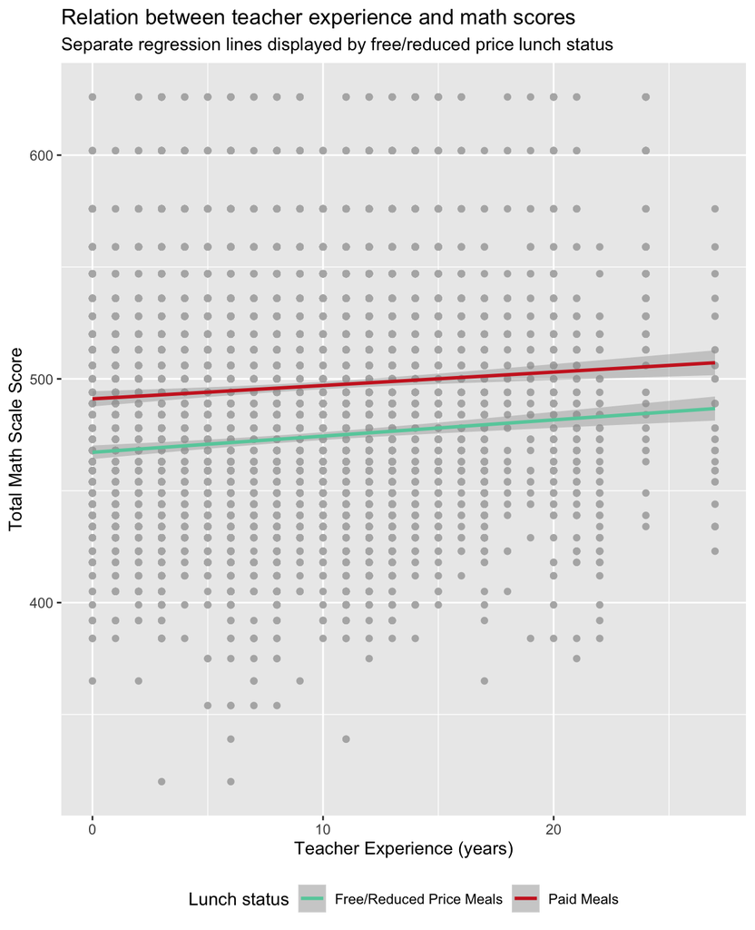

Wehman et al. (2014) conducted a case study to examine the the effect of supported employment on vocational rehabilitation outcomes of transition-age youth. Other researchers examined the exmployability skills for entry-level employees with and without disabilities (Ju, Roberts, and Zhang 2013).

# Methods

We report how we determined our sample size, all data exclusions (if any), all manipulations, and all measures in the study.

## Participants

## Material

## Procedure

## Data analysis

We used R (Version 3.6.1; R Core Team 2019) and the R-packages *devtools* (Version 2.2.1; Wickham, Hester, and Chang 2019), *dplyr* (Version 0.8.3; Wickham et al. 2019), *forcats* (Version 0.4.0; Wickham 2019a), *ggplot2* (Version 3.2.1; Wickham 2016), *here* (Version 0.1; Müller 2017), *janitor* (Version 1.2.0; Firke 2019), *papaja* (Version 0.1.0.9842; Aust and Barth 2018), *purrr* (Version 0.3.2; Henry and Wickham 2019), *readr* (Version 1.3.1; Wickham, Hester, and Francois 2018), *rio* (Version 0.5.16; Chan et al. 2018), *stringr* (Version 1.4.0; Wickham 2019b), *tibble* (Version 2.1.3; Müller and Wickham 2019), *tidyr* (Version 1.0.0; Wickham and Henry 2019), *tidyverse* (Version 1.2.1; Wickham 2017), *tinytex* (Version 0.16; Xie 2019), and *usethis* (Version 1.5.1; Wickham and Bryan 2019) for all our analyses.

# Results

Figure 1 demonstrates the relationship between teacher experience and student’s math scale scores. The two regression lines demonstrate differences between free and reduced price lunch status, which students who are not eligible for free and reduced price lunch scoring, in general, higher than those who do. In general, it does not appear that teacher experience significantly impacts this difference, as math scores for students both with and without free and reduced price lunch status appears to increase at approximately the same rate.

# Discussion

# References

Aust, Frederik, and Marius Barth. 2018. *papaja: Create APA Manuscripts with R Markdown*. https://github.com/crsh/papaja.

Chan, Chung-hong, Geoffrey CH Chan, Thomas J. Leeper, and Jason Becker. 2018. *Rio: A Swiss-Army Knife for Data File I/O*.

Firke, Sam. 2019. *Janitor: Simple Tools for Examining and Cleaning Dirty Data*. https://CRAN.R-project.org/package=janitor.

Henry, Lionel, and Hadley Wickham. 2019. *Purrr: Functional Programming Tools*. https://CRAN.R-project.org/package=purrr.

Ju, Song, Eric Roberts, and Dalun Zhang. 2013. “Employer Attitudes Toward Workers with Disabilities: A Review of Research in the Past Decade.” *Journal of Vocational Rehabilitation* 38 (2). IOS Press: 113–23.

Müller, Kirill. 2017. *Here: A Simpler Way to Find Your Files*. https://CRAN.R-project.org/package=here.

Müller, Kirill, and Hadley Wickham. 2019. *Tibble: Simple Data Frames*. https://CRAN.R-project.org/package=tibble.

R Core Team. 2019. *R: A Language and Environment for Statistical Computing*. Vienna, Austria: R Foundation for Statistical Computing. https://www.R-project.org/.

Wehman, Paul, Fong Chan, Nicole Ditchman, and Hyun-Ju Kang. 2014. “Effect of Supported Employment on Vocational Rehabilitation Outcomes of Transition-Age Youth with Intellectual and Developmental Disabilities: A Case Control Study.” *Intellectual and Developmental Disabilities*.

Wickham, Hadley. 2016. *Ggplot2: Elegant Graphics for Data Analysis*. Springer-Verlag New York. https://ggplot2.tidyverse.org.

———. 2017. *Tidyverse: Easily Install and Load the ’Tidyverse’*. https://CRAN.R-project.org/package=tidyverse.

———. 2019a. *Forcats: Tools for Working with Categorical Variables (Factors)*. https://CRAN.R-project.org/package=forcats.

———. 2019b. *Stringr: Simple, Consistent Wrappers for Common String Operations*. https://CRAN.R-project.org/package=stringr.

Wickham, Hadley, and Jennifer Bryan. 2019. *Usethis: Automate Package and Project Setup*. https://CRAN.R-project.org/package=usethis.

Wickham, Hadley, Romain François, Lionel Henry, and Kirill Müller. 2019. *Dplyr: A Grammar of Data Manipulation*. https://CRAN.R-project.org/package=dplyr.

Wickham, Hadley, and Lionel Henry. 2019. *Tidyr: Easily Tidy Data with ’Spread()’ and ’Gather()’ Functions*. https://CRAN.R-project.org/package=tidyr.

Wickham, Hadley, Jim Hester, and Winston Chang. 2019. *Devtools: Tools to Make Developing R Packages Easier*. https://CRAN.R-project.org/package=devtools.

Wickham, Hadley, Jim Hester, and Romain Francois. 2018. *Readr: Read Rectangular Text Data*. https://CRAN.R-project.org/package=readr.

Xie, Yihui. 2019. *Tinytex: Helper Functions to Install and Maintain ’Tex Live’, and Compile ’Latex’ Documents*. https://CRAN.R-project.org/package=tinytex.